# Reproducible Research: Peer Assessment 1

Edgar Sánchez M.

March 30, 2018

## Prepare environment

```r
setwd("~/R/RepData_PeerAssessment1")
rm(list = ls())

unzip("activity.zip", overwrite = T)
```

## Loading and preprocessing the data

If the data.frame already exists then don’t load it again

```r
if ( !(exists("activity"))) {
  activity0 <- read.csv("activity.csv")
}
activity0$date <- as.Date(activity0$date, "%Y-%m-%d")
```

Setting all the NA’s to zero

```r
activity <- activity0
activity[is.na(activity$steps),]$steps <- 0
```

## What is mean total number of steps taken per day?

Calculate summary data.frame “**summary_sum**” by date

```r
activity_sum <- group_by(activity, date)  %>%
  summarise(totalSteps=sum(steps), meanSteps=mean(steps), medianSteps=median(steps)) %>%
  arrange(date)
activity_sum <- as.data.frame(activity_sum)
```

Create the histogram showing average steps taken by day

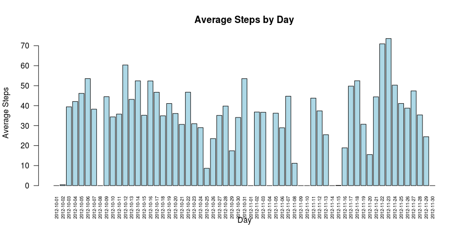

```r
barplot(
  activity_sum$meanSteps,
  names.arg = activity_sum$date,
  las = 2,
  cex.names=0.6,
  xlab = "Day",
  ylab = "Average Steps",
  main = "Average Steps by Day",
  col = "lightblue"
)
```

The mean and median steps per day is shown in the following table:

| Date | Mean Steps | Median Steps |
| --- | --- | --- |
| 2012-10-01 | 0.00 | 0.00 |
| 2012-10-02 | 0.44 | 0.00 |
| 2012-10-03 | 39.42 | 0.00 |
| 2012-10-04 | 42.07 | 0.00 |
| 2012-10-05 | 46.16 | 0.00 |
| 2012-10-06 | 53.54 | 0.00 |
| 2012-10-07 | 38.25 | 0.00 |
| 2012-10-08 | 0.00 | 0.00 |
| 2012-10-09 | 44.48 | 0.00 |
| 2012-10-10 | 34.38 | 0.00 |
| 2012-10-11 | 35.78 | 0.00 |
| 2012-10-12 | 60.35 | 0.00 |
| 2012-10-13 | 43.15 | 0.00 |
| 2012-10-14 | 52.42 | 0.00 |
| 2012-10-15 | 35.20 | 0.00 |
| 2012-10-16 | 52.38 | 0.00 |
| 2012-10-17 | 46.71 | 0.00 |
| 2012-10-18 | 34.92 | 0.00 |
| 2012-10-19 | 41.07 | 0.00 |
| 2012-10-20 | 36.09 | 0.00 |
| 2012-10-21 | 30.63 | 0.00 |
| 2012-10-22 | 46.74 | 0.00 |
| 2012-10-23 | 30.97 | 0.00 |
| 2012-10-24 | 29.01 | 0.00 |
| 2012-10-25 | 8.65 | 0.00 |
| 2012-10-26 | 23.53 | 0.00 |
| 2012-10-27 | 35.14 | 0.00 |
| 2012-10-28 | 39.78 | 0.00 |
| 2012-10-29 | 17.42 | 0.00 |
| 2012-10-30 | 34.09 | 0.00 |
| 2012-10-31 | 53.52 | 0.00 |
| 2012-11-01 | 0.00 | 0.00 |
| 2012-11-02 | 36.81 | 0.00 |
| 2012-11-03 | 36.70 | 0.00 |
| 2012-11-04 | 0.00 | 0.00 |
| 2012-11-05 | 36.25 | 0.00 |
| 2012-11-06 | 28.94 | 0.00 |
| 2012-11-07 | 44.73 | 0.00 |
| 2012-11-08 | 11.18 | 0.00 |
| 2012-11-09 | 0.00 | 0.00 |
| 2012-11-10 | 0.00 | 0.00 |
| 2012-11-11 | 43.78 | 0.00 |
| 2012-11-12 | 37.38 | 0.00 |
| 2012-11-13 | 25.47 | 0.00 |
| 2012-11-14 | 0.00 | 0.00 |
| 2012-11-15 | 0.14 | 0.00 |
| 2012-11-16 | 18.89 | 0.00 |
| 2012-11-17 | 49.79 | 0.00 |
| 2012-11-18 | 52.47 | 0.00 |
| 2012-11-19 | 30.70 | 0.00 |
| 2012-11-20 | 15.53 | 0.00 |
| 2012-11-21 | 44.40 | 0.00 |
| 2012-11-22 | 70.93 | 0.00 |
| 2012-11-23 | 73.59 | 0.00 |
| 2012-11-24 | 50.27 | 0.00 |
| 2012-11-25 | 41.09 | 0.00 |
| 2012-11-26 | 38.76 | 0.00 |
| 2012-11-27 | 47.38 | 0.00 |
| 2012-11-28 | 35.36 | 0.00 |
| 2012-11-29 | 24.47 | 0.00 |
| 2012-11-30 | 0.00 | 0.00 |

## What is the average daily activity pattern?

Summarize info by Interval, generate data.frame “**activity_sum1**”

```r
activity_sum1 <- group_by(activity, interval) %>%
    summarise(totalSteps = sum(steps), avgSteps = mean(steps))
```

Determine which interval has the maximum values

```r
maxInterval <- as.numeric( activity_sum1[activity_sum1$totalSteps == max(activity_sum1$totalSteps), 1] )
```

Which 5-minute interval, on average across all the days in the dataset, contains the maximum number of steps?

Answer: Interval **#835**

### Generate the time series plot

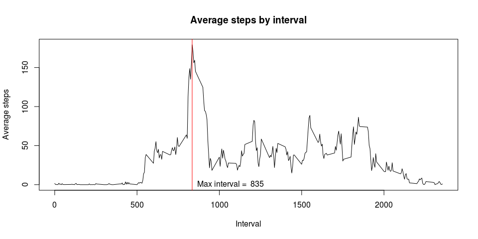

```r
plot(
  activity_sum1$interval,
  activity_sum1$avgSteps,
  type = "l",
  xlab = "Interval",
  ylab = "Average steps",
  main = "Average steps by interval"
)
abline( v = maxInterval, col = "red")
text( maxInterval, 0 , paste("Max interval = ", maxInterval) , pos=4)
```

## Imputing missing values

Obtain a vector with NA’s from the original data set:

```r
activityNAS <- activity0[ is.na( activity0$steps ), ]
numOfNas <- nrow( activityNAS )
```

The number of NA’s present in the original data set is: **2304**

We’re gonna use the **average number of steps per interval** to assign it to the NA values. For this we use data.frame “*activity_sum1*” created before.

```r
activityNAS <- merge( activityNAS, activity_sum1, all = T ) %>% select( steps=avgSteps, date, interval )
activity1 <- rbind( activity0[ !is.na( activity0$steps ), ] , activityNAS )
```

Summarize the modified data.frame, the result is stored in data.frame “**activity_sum2**”

```r
activity_sum2 <- group_by(activity1, date)  %>%
  summarise(totalSteps=sum(steps), meanSteps=mean(steps), medianSteps=median(steps), countSteps=n()) %>%
  arrange(date)
activity_sum2 <- as.data.frame(activity_sum2)
```

Generate the new plot with the NA values replaced

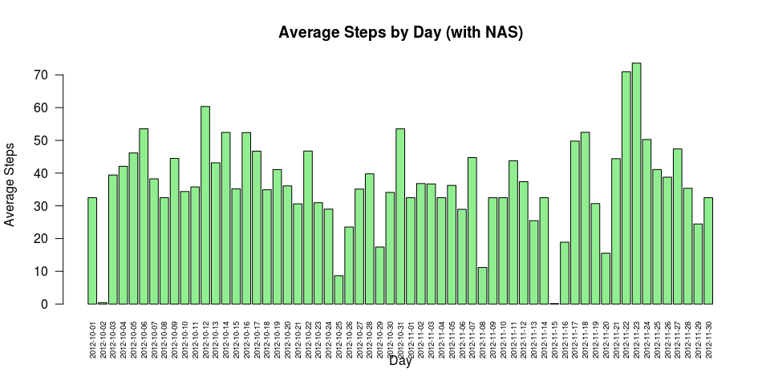

```r
barplot(
  activity_sum2$meanSteps,
  names.arg = activity_sum2$date,
  las = 2,
  cex.names=0.6,
  xlab = "Day",
  ylab = "Average Steps",
  main = "Average Steps by Day (with NAS)",
  col = "lightgreen"
)
```

The mean and median steps per day is shown in the following table:

| Date | Mean Steps | Median Steps |
| --- | --- | --- |
| 2012-10-01 | 32.48 | 29.64 |
| 2012-10-02 | 0.44 | 0.00 |
| 2012-10-03 | 39.42 | 0.00 |
| 2012-10-04 | 42.07 | 0.00 |
| 2012-10-05 | 46.16 | 0.00 |
| 2012-10-06 | 53.54 | 0.00 |
| 2012-10-07 | 38.25 | 0.00 |
| 2012-10-08 | 32.48 | 29.64 |
| 2012-10-09 | 44.48 | 0.00 |
| 2012-10-10 | 34.38 | 0.00 |
| 2012-10-11 | 35.78 | 0.00 |
| 2012-10-12 | 60.35 | 0.00 |
| 2012-10-13 | 43.15 | 0.00 |
| 2012-10-14 | 52.42 | 0.00 |
| 2012-10-15 | 35.20 | 0.00 |
| 2012-10-16 | 52.38 | 0.00 |
| 2012-10-17 | 46.71 | 0.00 |
| 2012-10-18 | 34.92 | 0.00 |
| 2012-10-19 | 41.07 | 0.00 |
| 2012-10-20 | 36.09 | 0.00 |
| 2012-10-21 | 30.63 | 0.00 |
| 2012-10-22 | 46.74 | 0.00 |
| 2012-10-23 | 30.97 | 0.00 |
| 2012-10-24 | 29.01 | 0.00 |
| 2012-10-25 | 8.65 | 0.00 |
| 2012-10-26 | 23.53 | 0.00 |
| 2012-10-27 | 35.14 | 0.00 |
| 2012-10-28 | 39.78 | 0.00 |
| 2012-10-29 | 17.42 | 0.00 |
| 2012-10-30 | 34.09 | 0.00 |
| 2012-10-31 | 53.52 | 0.00 |
| 2012-11-01 | 32.48 | 29.64 |
| 2012-11-02 | 36.81 | 0.00 |
| 2012-11-03 | 36.70 | 0.00 |
| 2012-11-04 | 32.48 | 29.64 |
| 2012-11-05 | 36.25 | 0.00 |
| 2012-11-06 | 28.94 | 0.00 |
| 2012-11-07 | 44.73 | 0.00 |
| 2012-11-08 | 11.18 | 0.00 |
| 2012-11-09 | 32.48 | 29.64 |
| 2012-11-10 | 32.48 | 29.64 |
| 2012-11-11 | 43.78 | 0.00 |
| 2012-11-12 | 37.38 | 0.00 |
| 2012-11-13 | 25.47 | 0.00 |
| 2012-11-14 | 32.48 | 29.64 |
| 2012-11-15 | 0.14 | 0.00 |
| 2012-11-16 | 18.89 | 0.00 |
| 2012-11-17 | 49.79 | 0.00 |
| 2012-11-18 | 52.47 | 0.00 |
| 2012-11-19 | 30.70 | 0.00 |
| 2012-11-20 | 15.53 | 0.00 |
| 2012-11-21 | 44.40 | 0.00 |
| 2012-11-22 | 70.93 | 0.00 |
| 2012-11-23 | 73.59 | 0.00 |
| 2012-11-24 | 50.27 | 0.00 |
| 2012-11-25 | 41.09 | 0.00 |
| 2012-11-26 | 38.76 | 0.00 |
| 2012-11-27 | 47.38 | 0.00 |
| 2012-11-28 | 35.36 | 0.00 |
| 2012-11-29 | 24.47 | 0.00 |
| 2012-11-30 | 32.48 | 29.64 |

## Are there differences in activity patterns between weekdays and weekends?

In order to determine the label for Weekdays and Weekends, the following function is defined:

```r
isWeekend <- function( x ){
  if( as.POSIXlt(x)$wday %in% c(0,6)){
    "Weekend"
  } else {
    "Weekday"
  }
}
```

If posix weekday number is 0 (Sunday) or 6 (Saturday), then the label is “Weekend” else it’s “Weekday”

Use the function to generate column labeling what type of day it is

```r
weekDayVect <- sapply( activity1$date, isWeekend )
activity1 <- cbind( activity1, dayType = weekDayVect)
```

Summarize the information by DayType and Interval

```r
plot_data <- aggregate(steps~ dayType + interval, data=activity1 , mean )
```

Generate plot, there is more step activity during the first intervals of Weekdays:

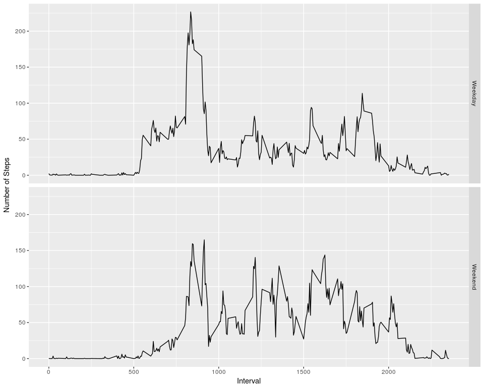

```r
daysType <- qplot(
              interval,
              steps,
              data=plot_data,
              facets=dayType~. ,
              geom = "line",
              xlab = "Interval",
              ylab = "Number of Steps"
            )
print(daysType)
```